# R Notebook

# Case Study 1: How Does a Bike-Share Navigate Speedy Success?

## Introduction

Welcome to the Cyclistic bike-share analysis case study! In this case study, you will perform many real-world tasks of a junior data analyst.

You will work for a fictional company, Cyclist, and meet different characters and team members. In order to answer the key business questions, you will follow the steps of the data analysis process: ask, prepare, process, analyze, share, and act. Along the way, the Case Study Roadmap tables — including guiding questions and key tasks — will help you stay on the right path.

By the end of this lesson, you will have a portfolio-ready case study. Download the packet and reference the details of this case study anytime. Then, when you begin your job hunt, your case study will be a tangible way to demonstrate your knowledge and skills to potential employers.

## Scenario

You are a junior data analyst working in the marketing analyst team at Cyclistic, a bike-share company in Chicago. The director of marketing believes the company’s future success depends on maximizing the number of annual memberships. Therefore, your team wants to understand how casual riders and annual members use Cyclistic bikes differently.

From these insights, your team will design a new marketing strategy to convert casual riders into annual members. But first, Cyclistic executives must approve your recommendations, so they must be backed up with compelling data insights and professional data visualizations.

## Ask

Three questions will guide the future marketing program:

> 1. How do annual members and casual riders use **Cyclistic** bikes differently?

> 2. Why would casual riders buy **Cyclistic** annual memberships?

> 3. How can **Cyclistic** use digital media to influence casual riders to become members?

## Prepare

```r
install.packages("geosphere")
```

```
Error in install.packages : Updating loaded packages
```

```r
library(tidyverse) # for data wrangling
library(lubridate) # for wrangling data attributes
library(ggplot2) # for visualizations
library(dplyr)
library(geosphere)
```

### Load data

```r
library(readr)
```

```r
getwd()
```

```
[1] "/home/digdata/Documents/code-all/coursera-courses/case-study/case_study_ciclyst"
```

```r
cyclist_raw_04 <- read_csv("case_study_da_bike/ciclyst_csv/202004-divvy-tripdata.csv")
```

```r
cyclist_raw_05 <- read_csv("case_study_da_bike/ciclyst_csv/202005-divvy-tripdata.csv")
```

```r
cyclist_raw_06  <- read_csv("case_study_da_bike/ciclyst_csv/202006-divvy-tripdata.csv")
```

```r
cyclist_raw_07  <- read_csv("case_study_da_bike/ciclyst_csv/202007-divvy-tripdata.csv")
```

[output not shown]

```r
cyclist_raw_08 <- read_csv("case_study_da_bike/ciclyst_csv/202008-divvy-tripdata.csv")
```

```r
cyclist_raw_09 <- read_csv("case_study_da_bike/ciclyst_csv/202009-divvy-tripdata.csv")
```

```r
cyclist_raw_10 <- read_csv("case_study_da_bike/ciclyst_csv/202010-divvy-tripdata.csv")
```

```r
cyclist_raw_11 <- read_csv("case_study_da_bike/ciclyst_csv/202011-divvy-tripdata.csv")
```

```r
cyclist_raw_12 <- read_csv("case_study_da_bike/ciclyst_csv/202012-divvy-tripdata.csv")
```

```r
cyclist_raw_01 <- read_csv("case_study_da_bike/ciclyst_csv/202101-divvy-tripdata.csv")
```

```r
cyclist_raw_02 <- read_csv("case_study_da_bike/ciclyst_csv/202102-divvy-tripdata.csv")
```

```r
cyclist_raw_03 <- read_csv("case_study_da_bike/ciclyst_csv/202103-divvy-tripdata.csv")
```

## Merge

```r
cyclist_raw <- rbind(
  cyclist_raw_04,
  cyclist_raw_05,
  cyclist_raw_06,
  cyclist_raw_07,
  cyclist_raw_08,
  cyclist_raw_09,
  cyclist_raw_10,
  cyclist_raw_11,
  cyclist_raw_12,
  cyclist_raw_01,
  cyclist_raw_02,
  cyclist_raw_03,
    deparse.level = 1
)
```

```r
cyclist_raw
```

| ride_id | rideable_type | started_at | ended_at | start_station_name | start_station_id | end_station_name | end_station_id | start_lat | start_lng | end_lat | end_lng | member_casual |
| --- | --- | --- | --- | --- | --- | --- | --- | --- | --- | --- | --- | --- |
| A847FADBBC638E45 | docked_bike | 2020-04-26 17:45:14 | 2020-04-26 18:12:03 | Eckhart Park | 86 | Lincoln Ave & Diversey Pkwy | 152 | 41.8964 | -87.6610 | 41.9322 | -87.6586 | member |
| 5405B80E996FF60D | docked_bike | 2020-04-17 17:08:54 | 2020-04-17 17:17:03 | Drake Ave & Fullerton Ave | 503 | Kosciuszko Park | 499 | 41.9244 | -87.7154 | 41.9306 | -87.7238 | member |
| 5DD24A79A4E006F4 | docked_bike | 2020-04-01 17:54:13 | 2020-04-01 18:08:36 | McClurg Ct & Erie St | 142 | Indiana Ave & Roosevelt Rd | 255 | 41.8945 | -87.6179 | 41.8679 | -87.6230 | member |
| 2A59BBDF5CDBA725 | docked_bike | 2020-04-07 12:50:19 | 2020-04-07 13:02:31 | California Ave & Division St | 216 | Wood St & Augusta Blvd | 657 | 41.9030 | -87.6975 | 41.8992 | -87.6722 | member |
| 27AD306C119C6158 | docked_bike | 2020-04-18 10:22:59 | 2020-04-18 11:15:54 | Rush St & Hubbard St | 125 | Sheridan Rd & Lawrence Ave | 323 | 41.8902 | -87.6262 | 41.9695 | -87.6547 | casual |
| 356216E875132F61 | docked_bike | 2020-04-30 17:55:47 | 2020-04-30 18:01:11 | Mies van der Rohe Way & Chicago Ave | 173 | Streeter Dr & Grand Ave | 35 | 41.8969 | -87.6217 | 41.8923 | -87.6120 | member |
| A2759CB06A81F2BC | docked_bike | 2020-04-02 14:47:19 | 2020-04-02 14:52:32 | Streeter Dr & Grand Ave | 35 | Fairbanks St & Superior St | 635 | 41.8923 | -87.6120 | 41.8957 | -87.6201 | member |
| FC8BC2E2D54F35ED | docked_bike | 2020-04-07 12:22:20 | 2020-04-07 13:38:09 | Ogden Ave & Roosevelt Rd | 434 | Western Ave & Congress Pkwy | 382 | 41.8665 | -87.6847 | 41.8747 | -87.6864 | casual |
| 9EC5648678DE06E6 | docked_bike | 2020-04-15 10:30:11 | 2020-04-15 10:35:55 | LaSalle Dr & Huron St | 627 | Larrabee St & Division St | 359 | 41.8949 | -87.6323 | 41.9035 | -87.6434 | casual |
| A8FFF89140C33017 | docked_bike | 2020-04-04 15:02:28 | 2020-04-04 15:19:47 | Kedzie Ave & Lake St | 377 | Central Park Ave & North Ave | 508 | 41.8846 | -87.7063 | 41.9097 | -87.7166 | member |

[output cut: 990 more lines]

```r
??rbin
```

## Process

- Open your spreadsheet and create a column called “ride_length.”
- Calculate the length of each ride by subtracting the column “started_at” from the column “ended_at” (for example, =D2-C2) and format as HH:MM:SS using Format > Cells > Time > 37:30:55.

```r
cyclist_mod <- cyclist_raw
cyclist_mod
```

| ride_id | rideable_type | started_at | ended_at | start_station_name | start_station_id | end_station_name | end_station_id | start_lat | start_lng | end_lat | end_lng | member_casual |
| --- | --- | --- | --- | --- | --- | --- | --- | --- | --- | --- | --- | --- |
| A847FADBBC638E45 | docked_bike | 2020-04-26 17:45:14 | 2020-04-26 18:12:03 | Eckhart Park | 86 | Lincoln Ave & Diversey Pkwy | 152 | 41.8964 | -87.6610 | 41.9322 | -87.6586 | member |
| 5405B80E996FF60D | docked_bike | 2020-04-17 17:08:54 | 2020-04-17 17:17:03 | Drake Ave & Fullerton Ave | 503 | Kosciuszko Park | 499 | 41.9244 | -87.7154 | 41.9306 | -87.7238 | member |
| 5DD24A79A4E006F4 | docked_bike | 2020-04-01 17:54:13 | 2020-04-01 18:08:36 | McClurg Ct & Erie St | 142 | Indiana Ave & Roosevelt Rd | 255 | 41.8945 | -87.6179 | 41.8679 | -87.6230 | member |
| 2A59BBDF5CDBA725 | docked_bike | 2020-04-07 12:50:19 | 2020-04-07 13:02:31 | California Ave & Division St | 216 | Wood St & Augusta Blvd | 657 | 41.9030 | -87.6975 | 41.8992 | -87.6722 | member |
| 27AD306C119C6158 | docked_bike | 2020-04-18 10:22:59 | 2020-04-18 11:15:54 | Rush St & Hubbard St | 125 | Sheridan Rd & Lawrence Ave | 323 | 41.8902 | -87.6262 | 41.9695 | -87.6547 | casual |
| 356216E875132F61 | docked_bike | 2020-04-30 17:55:47 | 2020-04-30 18:01:11 | Mies van der Rohe Way & Chicago Ave | 173 | Streeter Dr & Grand Ave | 35 | 41.8969 | -87.6217 | 41.8923 | -87.6120 | member |
| A2759CB06A81F2BC | docked_bike | 2020-04-02 14:47:19 | 2020-04-02 14:52:32 | Streeter Dr & Grand Ave | 35 | Fairbanks St & Superior St | 635 | 41.8923 | -87.6120 | 41.8957 | -87.6201 | member |
| FC8BC2E2D54F35ED | docked_bike | 2020-04-07 12:22:20 | 2020-04-07 13:38:09 | Ogden Ave & Roosevelt Rd | 434 | Western Ave & Congress Pkwy | 382 | 41.8665 | -87.6847 | 41.8747 | -87.6864 | casual |
| 9EC5648678DE06E6 | docked_bike | 2020-04-15 10:30:11 | 2020-04-15 10:35:55 | LaSalle Dr & Huron St | 627 | Larrabee St & Division St | 359 | 41.8949 | -87.6323 | 41.9035 | -87.6434 | casual |
| A8FFF89140C33017 | docked_bike | 2020-04-04 15:02:28 | 2020-04-04 15:19:47 | Kedzie Ave & Lake St | 377 | Central Park Ave & North Ave | 508 | 41.8846 | -87.7063 | 41.9097 | -87.7166 | member |

[output cut: 990 more lines]

```r
cyclist_mod <- na.omit(cyclist_mod)
```

```r
cyclist_mod$ride_length <- cyclist_mod$ended_at - cyclist_mod$started_at
```

```r
interv <-interval(cyclist_mod$started_at, cyclist_mod$ended_at)
ride_length <- as.duration(interv)
```

```r
as.numeric(ride_length, "minutes")
as.numeric(ride_length, "hours")
```

```r
class(cyclist_mod$ended_at )
```

```
[1] "POSIXct" "POSIXt"
```

Note: Description of the classes `"POSIXlt"-> (year, month, day)` and `"POSIXct"-> (hour, min, sec)` representing calendar dates and times (to the nearest second).

```r
cyclist_mod$ride_length <- ride_length
```

```r
cyclist_mod
```

```r
cyclist_mod[cyclist_mod$ride_length < 0,]
```

```r
cyclist_mod <- cyclist_mod[cyclist_mod$ride_length > 60,]
cyclist_mod
```

```r
cyclist_long_ride <- cyclist_mod[cyclist_mod$ride_length > 30000 ,]
```

```r
start <- cbind(cyclist_mod$start_lng, cyclist_mod$start_lat)
end <- cbind(cyclist_mod$end_lng, cyclist_mod$end_lat)
```

```r
library(sp)
```

```r
pts_start <- SpatialPoints(start)
pts_end <- SpatialPoints(end)
```

```r
dist_short_station <- distHaversine(pts_start, pts_end, r= 6378137)
```

```
Coordinate reference system of SpatialPoints object is not set. Assuming it is degrees (longitude/latitude)!Coordinate reference system of SpatialPoints object is not set. Assuming it is degrees (longitude/latitude)!
```

```r
cyclist_mod$dist_short_between_stations <- dist_short_station
```

- Create a column called “day_of_week,” and calculate the day of the week that each ride started using the “WEEKDAY” command (for example, =WEEKDAY(C2,1)) in each file. Format as General or as a number with no decimals, noting that 1 = Sunday and 7 = Saturday

```r
# 1 = Sunday and 7 = Saturday
day_of_week <- wday(cyclist_mod$started_at)
```

```r
cyclist_mod$day_of_week <- day_of_week
```

```r
cyclist_mod
```

[output not shown]

[output cut: 990 more lines]

## Analyze

4. Run a few calculations in one file to get a better sense of the data layout. Options:

> ● Calculate the mean of ride_length

> ● Calculate the max ride_length

> ● Calculate the mode of day_of_week

```r
summary(cyclist_mod)
```

```r
max(cyclist_mod$ride_length)
```

```
[1] 3523202
```

```r
min(cyclist_mod$ride_length)
```

```
[1] 61
```

```r
mean(cyclist_mod$ride_length)
```

```
[1] 1705.163
```

```r
library(modeest)
```

```r
mlv(cyclist_mod$day_of_week, method = "mfv")
```

```
[1] 7
```

Create a pivot table to quickly calculate and visualize the data. Options:

● Calculate the average ride_length for members and casual riders. Try rows = member_casual; Values = Average of ride_length.

● Calculate the average ride_length for users by day_of_week. Try columns = day_of_week; Rows = member_casual; Values = Average of ride_length.

● Calculate the number of rides for users by day_of_week by adding Count of trip_id to Values.

```r
aggregate(cyclist_mod$ride_length, list(cyclist_mod$member_casual), mean)
```

| Group.1 | x |
| --- | --- |
| casual | 2755.5362 |
| member | 970.3466 |

```r
library(magrittr) # needs to be run every time you start R and want to use %>%
library(dplyr)    # alternatively, this also loads %>%
```

```r
cyclist_mod %>%
  group_by(member_casual)  %>%
  summarise_at(vars(ride_length), funs(mean(., na.rm=TRUE)))
```

[output not shown]

| member_casual | ride_length |
| --- | --- |
| casual | 2755.5362 |
| member | 970.3466 |

```r
NA
```

```r
day_ride_length <- cyclist_mod %>%
  group_by(day_of_week, member_casual)  %>%
  summarise_at(vars(ride_length ), funs(mean(., na.rm=TRUE)))
```

```r
day_ride_length
```

| day_of_week | member_casual | ride_length |
| --- | --- | --- |
| 1 | casual | 3094.5130 |
| 1 | member | 1106.5548 |
| 2 | casual | 2762.1848 |
| 2 | member | 918.6968 |
| 3 | casual | 2485.3000 |
| 3 | member | 911.4681 |
| 4 | casual | 2481.8616 |
| 4 | member | 915.9959 |
| 5 | casual | 2645.5079 |
| 5 | member | 914.4293 |

[output cut: 4 more lines]

```r
cyclist_long_ride %>%
  group_by(day_of_week)  %>%
  summarise(ride_id) %>%
  count()
```

| day_of_week | n |
| --- | --- |
| 1 | 1226 |
| 2 | 751 |
| 3 | 692 |
| 4 | 714 |
| 5 | 806 |
| 6 | 1050 |
| 7 | 1413 |

```r
test <- cyclist_mod %>%
  mutate(weekday = wday(started_at, label = TRUE)) %>%  #creates weekday field using wday()
  group_by(member_casual, weekday) %>%  #groups by usertype and weekday
  summarise(number_of_rides = n()                           #calculates the number of rides and average duration
  ,average_duration = mean(ride_length)) %>%        # calculates the average duration
  arrange(member_casual, weekday)                               # sorts
```

```r
View(test)
```

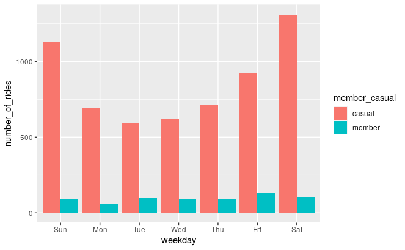

```r
cyclist_long_ride %>%
  mutate(weekday = wday(started_at, label = TRUE)) %>%
  group_by(member_casual, weekday) %>%
  summarise(number_of_rides = n()
            ,average_duration = mean(ride_length)) %>%
  arrange(member_casual, weekday)  %>%
  ggplot(aes(x = weekday, y = number_of_rides, fill = member_casual)) +
  geom_col(position = "dodge")
```

```r
plot(cyclist_mod$ride_length~cyclist_mod$dist_short_station)
```

[output not shown]